# Выбор модели для набора данных (Константа NA в категорийных, Медиана в числовых, Линейная нормализация)

Alexey Shovkun

29 сентября 2015 г.

# Выбор используемых параметров

Для обучения модели мы можем использовать не все доступные параметры, в частности мы исключаем низкоинформативные параметры.

Исключаем следующие параметры с низкой информативностью:

```
##     freqRatio percentUnique zeroVar  nzv
## x1   58.15054    0.10661928   FALSE TRUE
## x2   34.41270    0.02665482   FALSE TRUE
## x3   88.30400    0.02665482   FALSE TRUE
## x5   52.16908    0.06219458   FALSE TRUE
## x6  129.87209    0.01776988   FALSE TRUE
## x7   39.05338    0.01776988   FALSE TRUE
## x22  20.07170    0.07107952   FALSE TRUE
```

При построении модели каждая категориальная переменная разворачиваются в набор бинарных переменных (со занчениями 0 ли 1), число которых равно количеству категорий у категориальной переменной. Посмотрим на количество уникальных значений (категорий) для наших категориальных переменных:

```
##   x0   x1   x2   x3   x4   x5   x9  x10  x11  x12  x14  x15  x16  x17  x18
##   85   12    3    3    6    7    8 1263    5    8   33    3   10   73 1890
##  x19  x20  x21  x22
##   11   77 2471    8
```

Исключаем из рассмотрения следующие Категорийные параметры, у которых количество категорий >11: **x0, x1, x10, x14, x17, x18, x20, x21**.

Для первоначальной отладки будем использовать еще более сокращенный вариант, в котором отсечены параметры с числом категорий >3: **x0, x1, x4, x5, x9, x10, x11, x12, x14, x16, x17, x18, x19, x20, x21, x22

### Boosted Generalized Linear Model (glmboost)

Это продвинутый (boosted) вариант логистической регресии, один из самых базовых методов классификации, поэтому начнем с него. Модель строим на основе **всех параметров** пользователя, поскольку это, во-первых, дает немного лучшие результаты, а во-вторых, что самое важное, позволит нам получить альтернативный набор наиболее значимых параметров пользователя для построения других моделей.

Несмотря на невысокую точность модели, проведем ее анализ с целью определить, какие параметры пользователя оказывали наибольшее влияние на результат.

Проведем анализ сдвига/разброса модели на основе Bossted GLM с параметрами:

- применения метода boosting (уже),
- добавления параметров пользователя.

### Penalized Logistic Regression (plr)

Нам не удалось выявить наиболее важные параметры путем применения glmboost, попробуем сделать это методом plr, который также является разновиностью логистической регрессии.

Ничего путного этот метод не дал.

### Дерево решений (Decision Tree, rpart)

Потерпели неудачу с Boosted GLM. попробуем построить простую модель - дерево решений.

Применяем метод Cost-Sensitive Classification And Regression Tree (CART), чтобы иметь возможность противостоять потенциально высокому разбросу (переобучению) модели за счет параметра Cost.

```
## n= 11255
##
## node), split, n, loss, yval, (yprob)
##       * denotes terminal node
##
##   1) root 11255 7705 2 (0.0073 0.039 0.32 0.29 0.2 0.11 0.036)
##     2) x8>=0.9670249 3181  623 2 (0.0047 0.054 0.8 0.047 0.047 0.034 0.0094)
##       4) x8>=0.9714216 183   69 1 (0 0.62 0.25 0.033 0.066 0.016 0.016) *
##       5) x8< 0.9714216 2998  485 2 (0.005 0.02 0.84 0.048 0.045 0.035 0.009) *
##     3) x8< 0.9670249 8074 4921 3 (0.0083 0.033 0.12 0.39 0.26 0.14 0.046)
##       6) x8>=0.9621397 3703 1009 3 (0.0086 0.018 0.13 0.73 0.057 0.039 0.02)
##        12) x8>=0.9665364 556  306 2 (0.0036 0.009 0.45 0.37 0.083 0.061 0.023)
##          24) x56>=0.5512769 139   42 2 (0 0 0.7 0.22 0.043 0.036 0) *
##          25) x56< 0.5512769 417  242 3 (0.0048 0.012 0.37 0.42 0.096 0.07 0.031) *
##        13) x8< 0.9665364 3147  659 3 (0.0095 0.019 0.073 0.79 0.052 0.035 0.02) *
##       7) x8< 0.9621397 4371 2477 4 (0.008 0.047 0.12 0.11 0.43 0.22 0.068)
##        14) x8>=0.956766 2427  745 4 (0.0087 0.059 0.091 0.084 0.69 0.05 0.014) *
##        15) x8< 0.956766 1944 1097 5 (0.0072 0.032 0.15 0.13 0.11 0.44 0.14)
##          30) x8< 0.9523693 914  688 6 (0.0055 0.043 0.19 0.21 0.18 0.12 0.25)
##            60) x8< 0.9428432 628  460 3 (0.008 0.048 0.24 0.27 0.23 0.16 0.048)
##             120) x30>=0.003132408 195  107 2 (0.0051 0.13 0.45 0.28 0.11 0.021 0) *
##             121) x30< 0.003132408 433  311 4 (0.0092 0.012 0.14 0.26 0.28 0.22 0.069)
##               242) x57>=0.3097179 136   71 3 (0.0074 0.0074 0.12 0.48 0.18 0.13 0.074) *
##               243) x57< 0.3097179 297  199 4 (0.01 0.013 0.15 0.16 0.33 0.27 0.067) *
##            61) x8>=0.9428432 286   90 6 (0 0.031 0.094 0.08 0.07 0.038 0.69) *
##          31) x8>=0.9523693 1030  295 5 (0.0087 0.022 0.11 0.062 0.047 0.71 0.037) *
```

```
## rpart variable importance
##
##   only 20 most important variables shown (out of 89)
##
##                     Overall
## x8                 100.0000
## x57                 20.8050
## x58                 17.6341
## x30                 16.1235
## x56                 11.6838
## x59                  5.1713
## x29                  3.3485
## x1191bb549494        3.3229
## x12e33c63cf35        2.9422
## x9f67f142e40         0.9576
## x48aa82606c6         0.4334
## x23                  0.1781
## x35                  0.1623
## x32                  0.1589
## x11669ea3d319        0.1459
## x44                  0.0000
## `x19Не определено`   0.0000
## x33                  0.0000
## x19dd9c9e0da2        0.0000
## x40                  0.0000
```

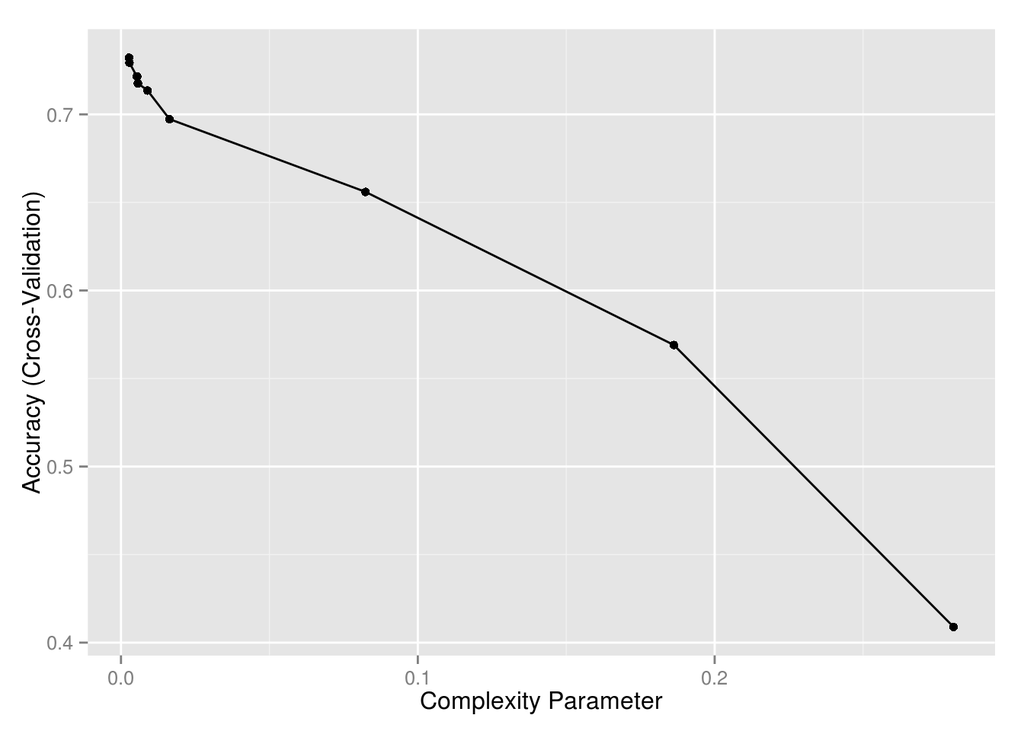

[figure not shown]

Получаем неплохую точность определения возрастной группы пользователей ~73%. Смущает факт. что в модели используется всего несколько переменных для определения возрастной группы. Возможно, это ее слабое место, ограничивающее максимальную достижимую точность.

Проведем анализ сдвига/разброса на основе Дерева решений c параметрами:

- cp = **0.0027255**.

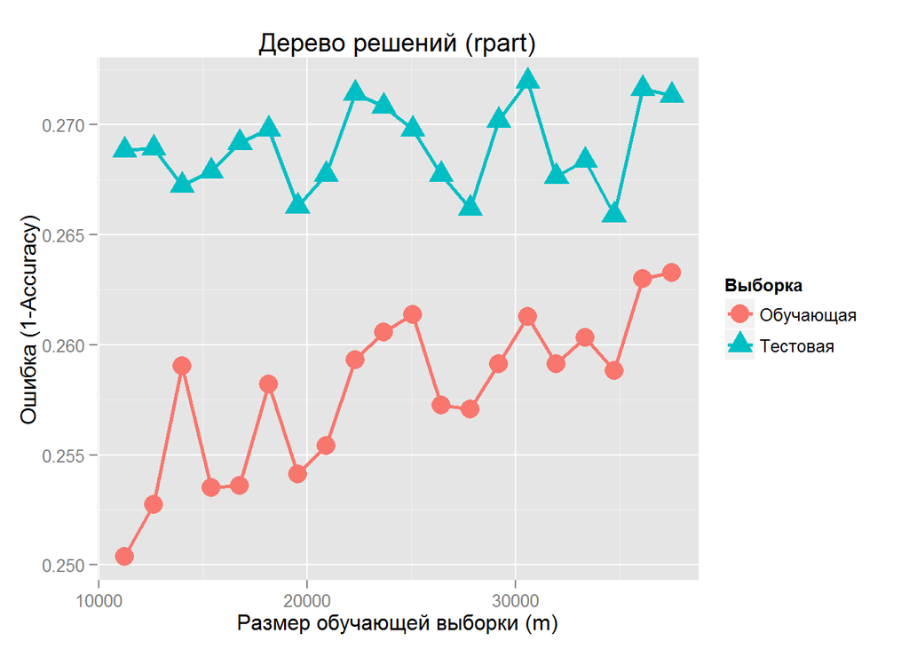

### Случайный лес (Random Forest, rf)

Дерево решений дало неплохой результат в качестве отправной точки. Попробуем усилить ее за счет применения модели Случайный лес.

```
##    user  system elapsed
##   7.615   0.073  63.662
```

```
## Random Forest
##
## 11255 samples
##    48 predictors
##     7 classes: '0', '1', '2', '3', '4', '5', '6'
##
## No pre-processing
## Resampling: Cross-Validated (10 fold)
##
## Summary of sample sizes: 10130, 10128, 10130, 10129, 10131, 10128, ...
##
## Resampling results across tuning parameters:
##
##   mtry  Accuracy   Kappa      Accuracy SD  Kappa SD
##    2    0.5389585  0.3541425  0.01377156   0.01986913
##    3    0.5875585  0.4297753  0.01288651   0.01745740
##    4    0.6165173  0.4723508  0.01262443   0.01836851
##    7    0.6664574  0.5448061  0.01149847   0.01644236
##   14    0.7157697  0.6157359  0.01209892   0.01648571
##   16    0.7215461  0.6246463  0.01008611   0.01340800
##   24    0.7351391  0.6445637  0.01136360   0.01514889
##   32    0.7412700  0.6537717  0.01357906   0.01799121
##   48    0.7426020  0.6557892  0.01362147   0.01800644
##
## Accuracy was used to select the optimal model using  the largest value.
## The final value used for the model was mtry = 48.
```

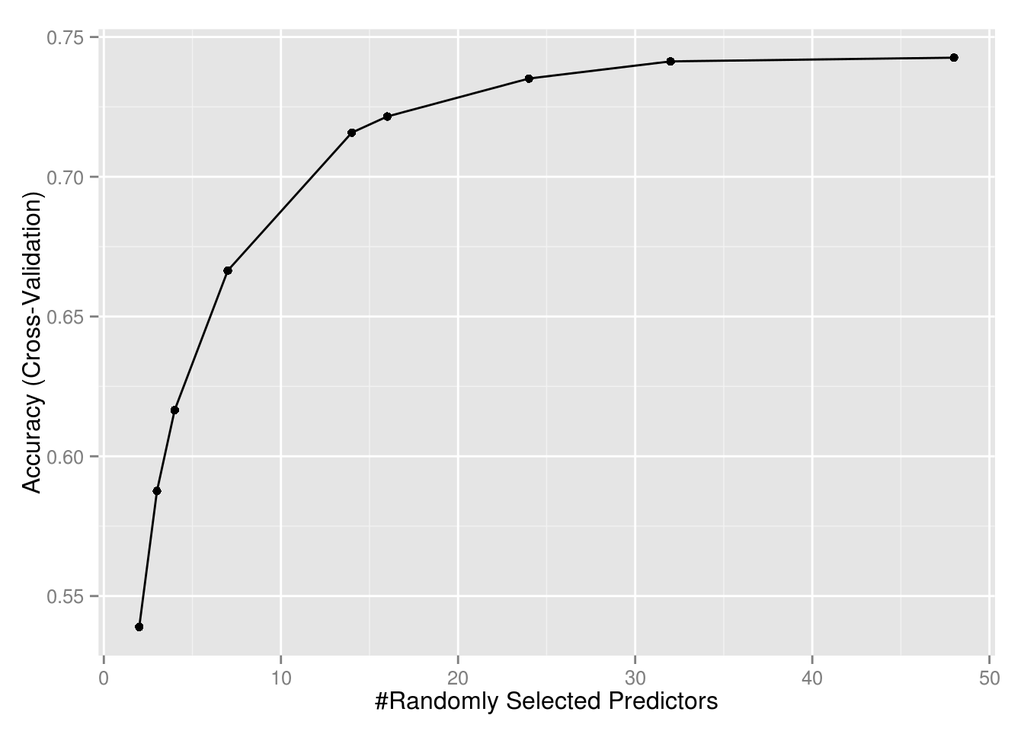

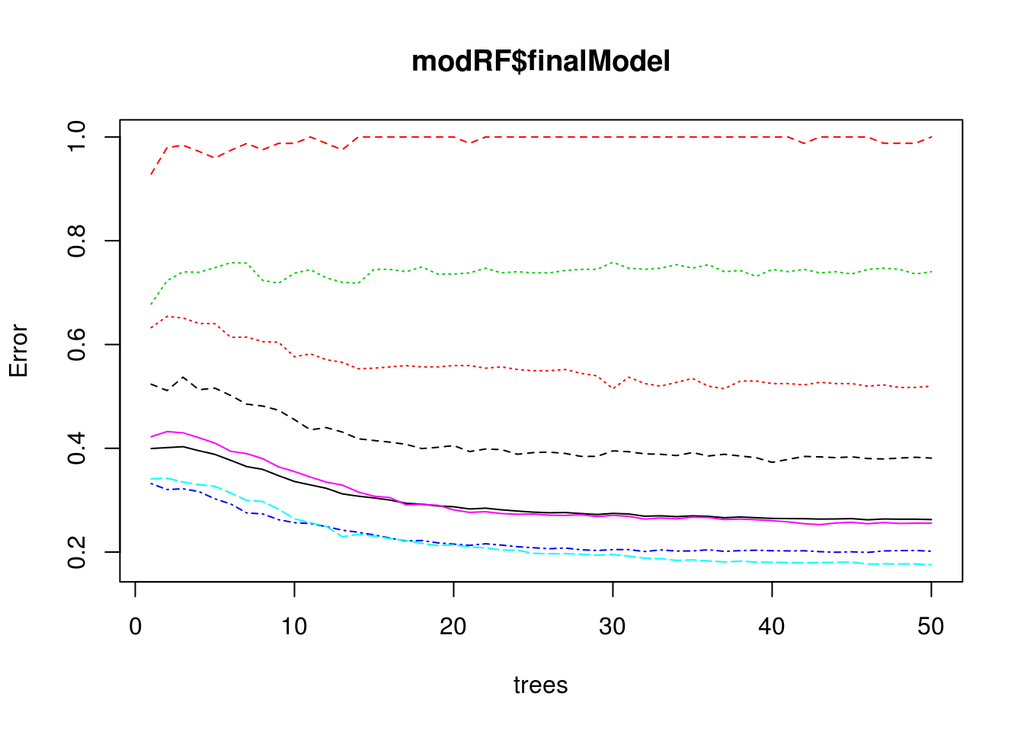

Проведем анализ сдвига/разброса на основе Случайного леса c параметром mtry =48.

```
##    user  system elapsed
##   0.176   0.016  80.862
```

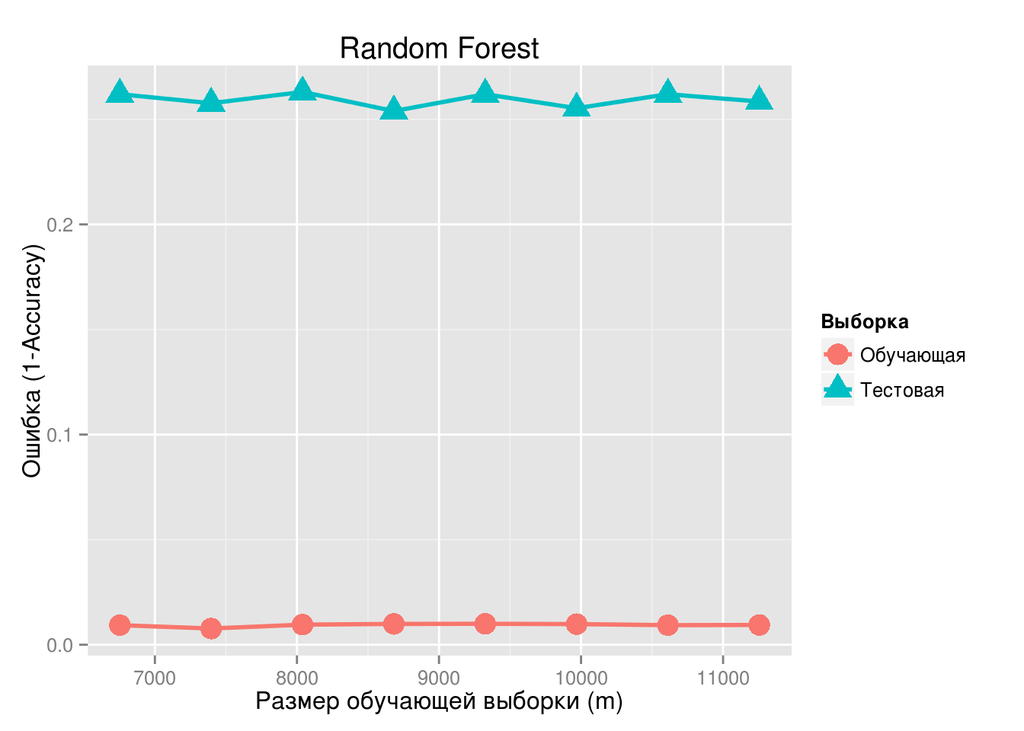

При nTree=50 график показывает, что обучающая ошибка постоянно равна 0, а тестовая ~ 25%. Это означает, что модель переобучена (имеет высокий разброс) и сдвинута (имеет высокий сдвиг). При nTree = 100 график показывает то же самое.

Чтобы побороть проблему переобучения, можно применть следующее:

- регуляризация (см. далее),
- уменьшить количество деревьев,
- попробовать на полной обучающей выборке,
- метод bagging,
- больше данных,
- сокращение (отбор) параметров.

### Случайный лес c регуляризацией (RRF)

Не будем пробовать, т.к. обычный случайный лес не дал существенно лучших результатов по сравнению с деревом решений.

### LogitBoost Classification Algorithm (Boosted Logistic Regression)

Попробуем еще один вариант логистической регрессии. А логистическая ли это регрессия?

Logitboost algorithm relies on a voting scheme to make classifications. Many (nIter of them) week classifiers are applied to each sample and their findings are used as votes to make the final classification. The class with the most votes “wins”. However, with this scheme it is common for two cases have a tie (the same number of votes), especially if number of iterations is even. In that case NA is returned, instead of a label. Train logitboost classification algorithm using decision stumps (one node decision trees) as weak learners.

```
##    user  system elapsed
##  31.259   0.288 212.283
```

```
## Boosted Logistic Regression
##
## 37502 samples
##    48 predictors
##     7 classes: '0', '1', '2', '3', '4', '5', '6'
##
## No pre-processing
## Resampling: Cross-Validated (10 fold)
##
## Summary of sample sizes: 33752, 33752, 33753, 33751, 33751, 33752, ...
##
## Resampling results across tuning parameters:
##
##   nIter  Accuracy   Kappa      Accuracy SD  Kappa SD
##   20     0.7709157  0.6897355  0.007476782  0.010106714
##   21     0.7782718  0.6999806  0.006615587  0.008962107
##   22     0.7682521  0.6855023  0.006787088  0.009004894
##   30     0.7707532  0.6894436  0.006447203  0.008552164
##   59     0.7739537  0.6930150  0.005857256  0.008677606
##   60     0.7710666  0.6898467  0.005562986  0.007715670
##   61     0.7748095  0.6949653  0.005636459  0.007852379
##   80     0.7713553  0.6907467  0.003564486  0.005188747
##
## Accuracy was used to select the optimal model using  the largest value.
## The final value used for the model was nIter = 21.
```

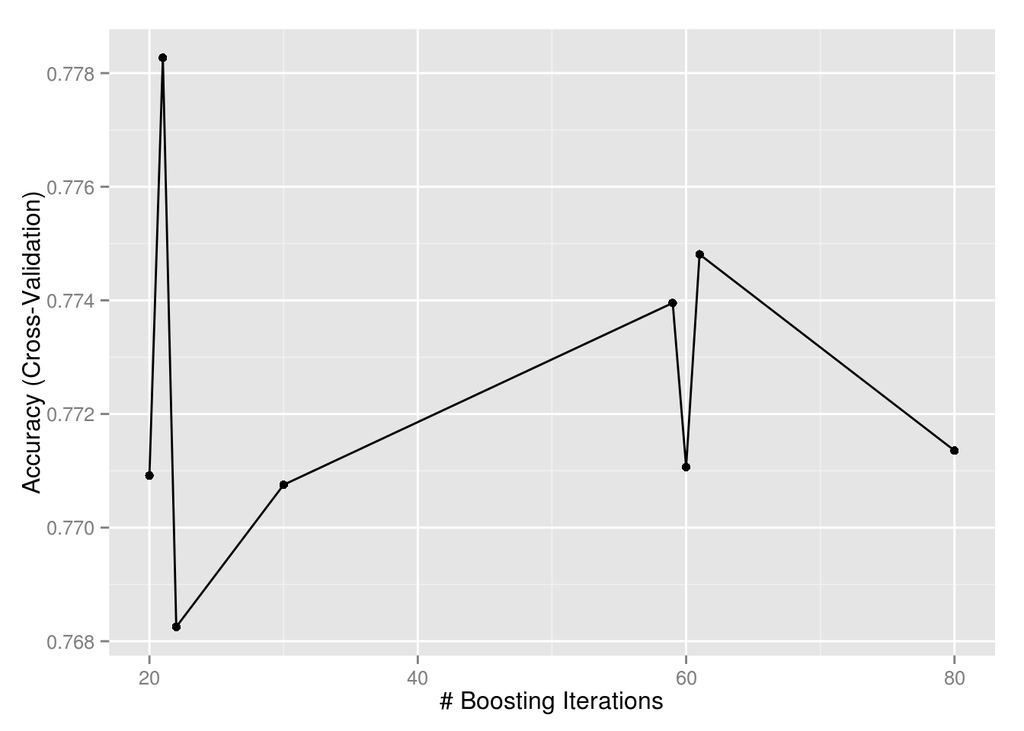

```
## ROC curve variable importance
##
##   variables are sorted by maximum importance across the classes
##   only 20 most important variables shown (out of 48)
##
##        X0    X1     X2    X3    X4    X5     X6
## x8  75.13 75.81 100.00 83.89 91.51 97.16 100.00
## x30 74.30 94.06  80.87 61.21 75.03 87.37  94.06
## x29 61.90 85.33  80.71 69.55 50.85 68.83  85.33
## x56 75.47 58.02  75.47 62.45 63.22 59.28  73.42
## x59 60.00 69.87  54.17 52.94 48.33 69.87  40.20
## x11 64.88 69.24  61.52 50.55 34.26 60.59  69.24
## x55 57.85 67.04  55.03 57.70 56.77 65.98  67.04
## x31 44.33 66.10  58.72 47.48 36.10 51.75  66.10
## x57 48.18 63.05  64.96 64.96 57.34 58.76  51.19
## x58 45.10 39.47  63.75 61.03 63.75 49.75  53.32
## x23 44.29 62.39  35.96 56.28 62.39 60.48  55.71
## x35 30.07 59.73  54.31 26.16 37.97 48.67  59.73
## x43 32.32 58.97  56.98 49.41 39.05 41.10  58.97
## x12 58.24 58.83  52.92 45.94 34.71 45.59  58.83
## x34 27.18 57.09  52.50 22.14 33.15 44.75  57.09
## x40 35.75 51.81  56.29 50.27 42.95 32.88  56.29
## x44 28.21 54.90  53.10 44.81 35.45 38.12  54.90
## x60 46.17 52.61  54.35 41.56 39.49 33.46  54.35
## x32 44.51 51.48  39.95 24.85 35.00 44.60  51.48
## x26 37.48 49.61  46.88 38.71 37.55 29.96  49.61
```

Проведем анализ сдвига/разброса на основе LogitBoost c параметром nIter =**21**.

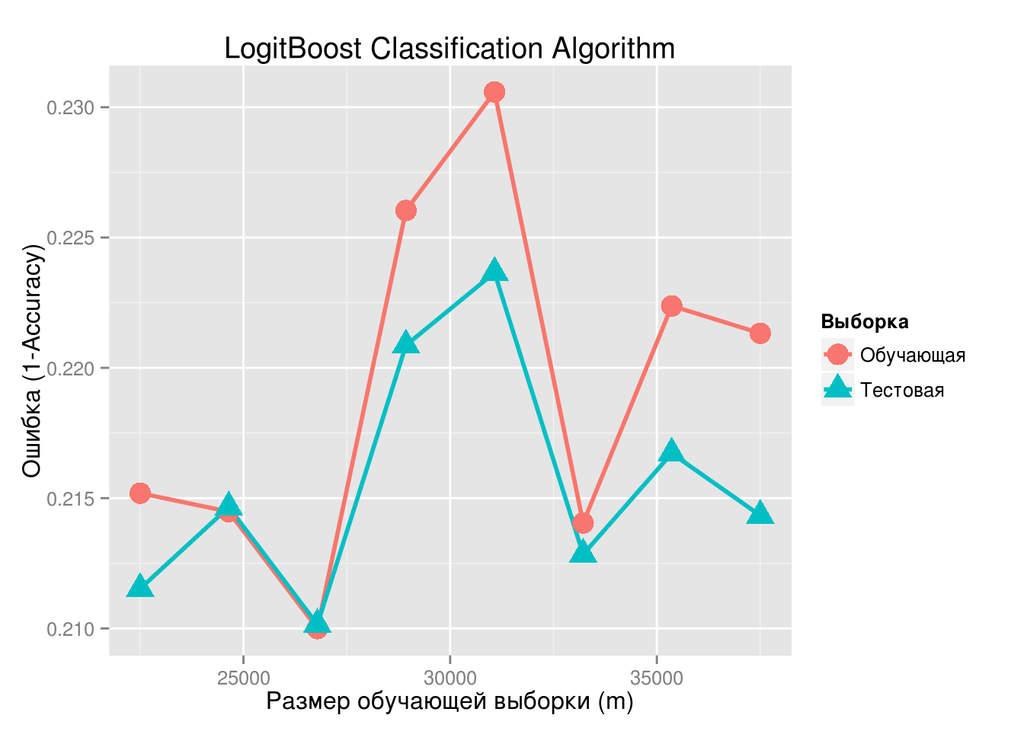

Модель показывает низкий уровень разброса и является хорошим кандидатом для финальной модели.

Результаты кажутся очень впечатляющими, однако, следует принять во внимание слудующую особенность модели LogitBoost. При одинаковом количестве голосов за два класса, модель в качестве прогноза выдает NA, которые не учитыватся при рассчете точности. Получается, что наиболее точная модель - та, которая выдает наибольшее количество NA. Попробуем другую модель с голосами, котолрая свободна от таких проблем.

### Продвинутое (boosted) Дерево решений (C5.0)

Предыдущий метод использовал набор одноуровневых деревьев для коллективного голосования, сейчас мы будем использовать сборку из многоуровневых деревьев.

```
##    user  system elapsed
##  63.249   0.080 228.422
```

```
##
## Call:
## C5.0.default(x = structure(c(0, 0, 0, 0, 0, 0, 0, 0, 0, 0, 0, 0, 0, 0,
##  0.0188399939242436, 0.00610150117524696,
##  0.0166877344379539, 0.000126149180416498, 0.000126149180416498, 0.
##
## Rule-Based Model
## Number of samples: 11255
## Number of predictors: 89
##
## Number of boosting iterations: 60 requested;  23 used due to early stopping
## Average number of rules: 151.9
##
## Non-standard options: attempt to group attributes
```

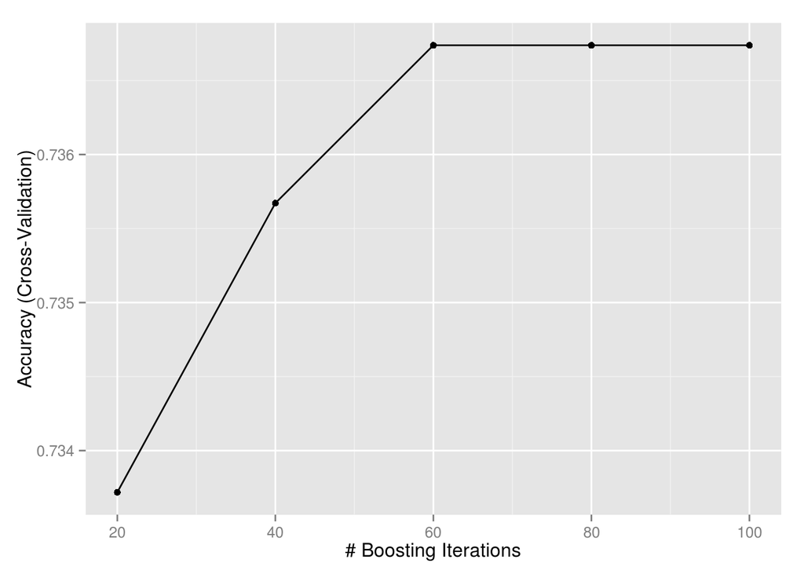

```
## [1] 0.7367379
```

Проведем анализ сдвига/разброса для Продвинутого дерева решений (C5.0):

- model = **rules**,
- winnow = **FALSE**,
- trials = **60**.

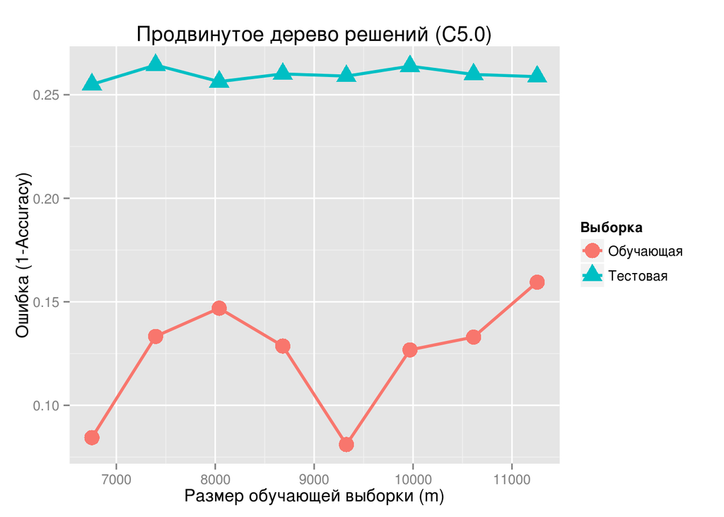

Модель переобучена.

### Stochastic Gradient Boosting, ~AdaBoost (gbm)

An implementation of extensions to Freund and Schapire’s AdaBoost algorithm and Friedman’s gradient boosting machine. Includes regression methods for least squares, absolute loss, t-distribution loss, quantile regression, logistic, multinomial logistic, Poisson, Cox proportional hazards partial likelihood, AdaBoost exponential loss, Huberized hinge loss, and Learning to Rank measures (LambdaMart). http://en.wikipedia.org/wiki/Gradient_boosting

Параметры модели:

- **n.minobsinnode** - minimum total weight needed in each node.It is used in the tree building process by ignoring any splits that lead to nodes containing fewer than this number of training set instances.
- **n.trees** - количество деревьев, которые будут построены.
- **interaction.depth** - the maximum depth of variable interactions. 1 implies an additive model, 2 implies a model with up to 2-way interactions, etc.

### Метод опорных векторов (Support Vector Machine)

Известно, что для задач классификации лучше подходит ядро на снове радиальной базисной функции или полиномиальное ядро, нежели чем линейное ядро. Тесты показывют, что лучще всего работает полиномиальное ядро, затем идут RBF и линейное ядра. Используем полиномиальное ядро. Эксперименты показали, что SVM Надо обучать сразу на большом объеме данных (или близком к нему). Это требует слишком много ресурсов. Отказываемся от SVM.

Значимыми являеются не все параметры, некоторые из них категорийные.

### Нейросеть с 1 уровнем (nnet)

?Можно применить нейросеть с предварительным отбором параметров на основе метода главных компонент (pcaNNet), но мы уже отобрали наиборлее информативные параметры, поэтому используем обычную одноуровневую нейросеть (nnet).

```
##     user   system  elapsed
##  148.375    0.111 1627.951
```

```
## Neural Network
##
## 37502 samples
##    48 predictors
##     7 classes: '0', '1', '2', '3', '4', '5', '6'
##
## No pre-processing
## Resampling: Cross-Validated (10 fold)
##
## Summary of sample sizes: 33752, 33753, 33751, 33752, 33752, 33752, ...
##
## Resampling results across tuning parameters:
##
##   decay  size  Accuracy   Kappa      Accuracy SD  Kappa SD
##   1e-04  6     0.6703115  0.5555528  0.037876899  0.052098989
##   1e-04  7     0.6665517  0.5513754  0.032561148  0.043806088
##   1e-04  8     0.6825774  0.5725936  0.026173722  0.035363134
##   1e-04  9     0.6797498  0.5691045  0.028439913  0.038647652
##   1e-03  6     0.6394024  0.5139255  0.030527622  0.041788995
##   1e-03  7     0.6722305  0.5588712  0.023729705  0.031973541
##   1e-03  8     0.6667907  0.5519195  0.026489833  0.035572404
##   1e-03  9     0.6780171  0.5671768  0.028419669  0.038823233
##   1e-02  6     0.6081288  0.4718043  0.009676791  0.012944831
##   1e-02  7     0.6088744  0.4728975  0.006913582  0.009118886
##   1e-02  8     0.6110874  0.4763934  0.006941421  0.009243584
##   1e-02  9     0.6094885  0.4742175  0.006694477  0.008790155
##
## Accuracy was used to select the optimal model using  the largest value.
## The final values used for the model were size = 8 and decay = 1e-04.
```

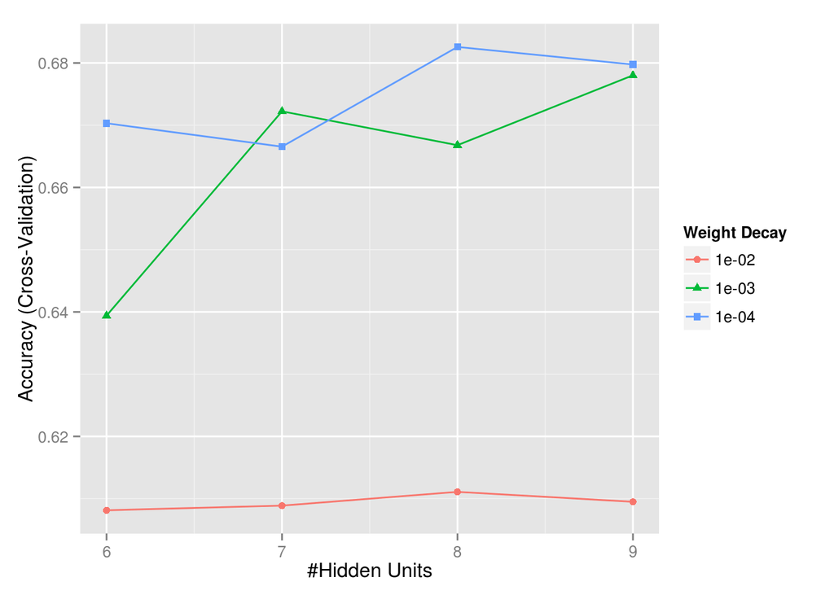

Проведем анализ полноты обучения для полученной нейросети nnet с параметрами:

- maxit = **500**,
- size = **8**,
- decay = **10^{-4}**.

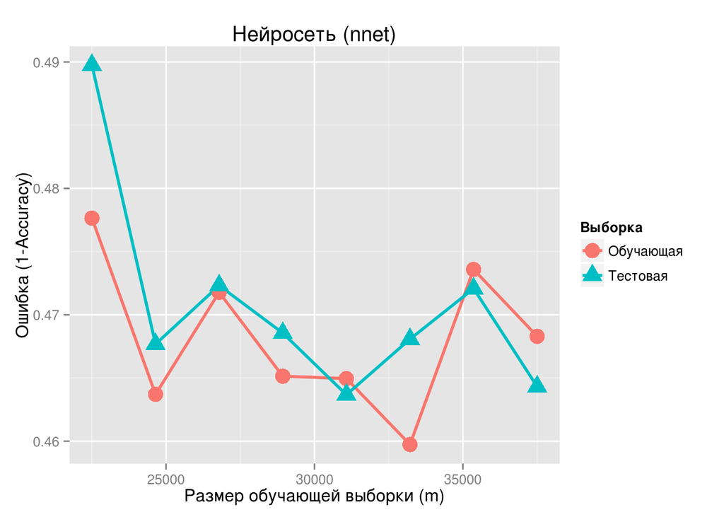

### Анализ качества обученных моделей

```
##                                 model  accuracy       variance
## 1               Decision Tree (rpart) 0.7362549        ?Низкий
## 2                       Random Forest 0.7419797 ?Очень высокий
## 3 LogitBoost Classification Algorithm 0.7782718         Низкий
## 4   Продвинутое дерево решений (C5.0) 0.7367379        Высокий
## 5               Neural network (nnet) 0.6825774         Низкий
```

Для моделей, которые показали хорошие резулььтаты (низкий разброс), проанализируем ROC кривые.

ВОПРОС: как это сделать в случае многоклассовой модели?

### Проверка лучшей модели на тестовой выборке

```
## Confusion Matrix and Statistics
##
##           Reference
## Prediction    0    1    2    3    4    5    6
##          0   23    0    0    0    0    0    0
##          1    0  204   46    5    8    5    0
##          2    7   83 3291  236  143  112   34
##          3   34   96  298 3183  196  123   65
##          4   17   89  197  172 2044   93   28
##          5    7   14   95   52   92 1005   38
##          6    2    5   16   21   20   16  283
##
## Overall Statistics
##
##                Accuracy : 0.8028
##                  95% CI : (0.7957, 0.8097)
##     No Information Rate : 0.3155
##     P-Value [Acc > NIR] : < 2.2e-16
##
##                   Kappa : 0.7377
##  Mcnemar's Test P-Value : NA
##
## Statistics by Class:
##
##                      Class: 0 Class: 1 Class: 2 Class: 3 Class: 4 Class: 5
## Sensitivity          0.255556  0.41548   0.8346   0.8675   0.8166  0.74225
## Specificity          1.000000  0.99467   0.9281   0.9080   0.9404  0.97326
## Pos Pred Value       1.000000  0.76119   0.8425   0.7967   0.7742  0.77130
## Neg Pred Value       0.994629  0.97653   0.9241   0.9428   0.9534  0.96883
## Prevalence           0.007201  0.03929   0.3155   0.2936   0.2003  0.10834
## Detection Rate       0.001840  0.01632   0.2633   0.2547   0.1635  0.08041
## Detection Prevalence 0.001840  0.02144   0.3125   0.3197   0.2112  0.10426
## Balanced Accuracy    0.627778  0.70507   0.8814   0.8878   0.8785  0.85775
##                      Class: 6
## Sensitivity           0.63170
## Specificity           0.99336
## Pos Pred Value        0.77961
## Neg Pred Value        0.98640
## Prevalence            0.03585
## Detection Rate        0.02264
## Detection Prevalence  0.02904
## Balanced Accuracy     0.81253
```